# Class 18 - In class exercises

Hari Subhash

Date created: 2019-05-09

### Task Set 1: For loop

Go here to check out the [basic elements of a for loop](https://puzhu.github.io/R4D/Classes/Class%2017/class17_slides.html#/a-common-recipe).

**TASK 1**: Load the gapminder dataset. Loop through its columns. If a column is numeric then store the output of the `summary()` command. If it is not numeric, then store NULL. Print the output.

| country | continent | year | lifeExp | pop | gdpPercap |
| --- | --- | --- | --- | --- | --- |
| Afghanistan | Asia | 1952 | 28.80100 | 8425333 | 779.4453 |
| Afghanistan | Asia | 1957 | 30.33200 | 9240934 | 820.8530 |
| Afghanistan | Asia | 1962 | 31.99700 | 10267083 | 853.1007 |
| Afghanistan | Asia | 1967 | 34.02000 | 11537966 | 836.1971 |
| Afghanistan | Asia | 1972 | 36.08800 | 13079460 | 739.9811 |
| Afghanistan | Asia | 1977 | 38.43800 | 14880372 | 786.1134 |
| Afghanistan | Asia | 1982 | 39.85400 | 12881816 | 978.0114 |
| Afghanistan | Asia | 1987 | 40.82200 | 13867957 | 852.3959 |
| Afghanistan | Asia | 1992 | 41.67400 | 16317921 | 649.3414 |
| Afghanistan | Asia | 1997 | 41.76300 | 22227415 | 635.3414 |

[output cut: 990 more lines]

```r
seq_along(gapminder)
```

```
[1] 1 2 3 4 5 6
```

```r
str(col_pos)
```

```
 int [1:6] 1 2 3 4 5 6
```

```r
identical(1:6, seq_along(gapminder))
```

```
[1] TRUE
```

The way to pull out a column from a dataset using base R syntax is `df[[i]]`

To get the number of columns in a df use `ncol()`

```r
ncol(gapminder)
```

```
[1] 6
```

```r
out_vec
```

[output not shown]

NOw lets setup the loop

```r
for (i in seq_along(gapminder)) {
    print(i)
}
```

```
[1] 1
[1] 2
[1] 3
[1] 4
[1] 5
[1] 6
```

```r
for (i in 1:6){
    print(i)
}
```

```
[1] 1
[1] 2
[1] 3
[1] 4
[1] 5
[1] 6
```

The next thing we want to do is pull out gapminder columns

```r
out_vec <- vector(mode = "list", length = ncol(gapminder))

for (i in seq_along(gapminder)) {
    ##pull out the ith column from gapminder
    gap_col <- gapminder[[i]]

    if (is.numeric(gap_col)) { ##check if this numeric
        out_vec[[i]] <- summary(gap_col)
    } else {
        out_vec[[i]] <- tibble(col1 = 1:3, col2 = c("a", "b", "c"))
    }
}
```

```r
out_vec
```

| col1 | col2 |
| --- | --- |
| 1 | a |
| 2 | b |
| 3 | c |

| col1 | col2 |
| --- | --- |
| 1 | a |
| 2 | b |
| 3 | c |

```
[[3]]
   Min. 1st Qu.  Median    Mean 3rd Qu.    Max.
   1952    1966    1980    1980    1993    2007

[[4]]
   Min. 1st Qu.  Median    Mean 3rd Qu.    Max.
  23.60   48.20   60.71   59.47   70.85   82.60

[[5]]
     Min.   1st Qu.    Median      Mean   3rd Qu.      Max.
6.001e+04 2.794e+06 7.024e+06 2.960e+07 1.959e+07 1.319e+09

[[6]]
    Min.  1st Qu.   Median     Mean  3rd Qu.     Max.
   241.2   1202.1   3531.8   7215.3   9325.5 113523.1
```

```r
out_vec
```

[output not shown]

You can use `names()` to both get and set the names of a vector. The code below `gets` the names of the `mtcars` dataset.

```r
names(mtcars)
```

```
 [1] "mpg"  "cyl"  "disp" "hp"   "drat" "wt"   "qsec" "vs"   "am"   "gear" "carb"
```

In the code below I use `names()` to set the column headers of a copy of the `mtcars` dataset called `mtcars_2`. See the output to notice how the column headings have been changed.

```r
## create a copy of the mtcars data
mtcars_2 <- mtcars

names(mtcars_2) <- paste0(names(mtcars), "_2")

mtcars_2
```

|  | mpg_2 | cyl_2 | disp_2 | hp_2 | drat_2 | wt_2 | qsec_2 | vs_2 | am_2 | gear_2 | carb_2 |
| --- | --- | --- | --- | --- | --- | --- | --- | --- | --- | --- | --- |
| Mazda RX4 | 21.0 | 6 | 160.0 | 110 | 3.90 | 2.620 | 16.46 | 0 | 1 | 4 | 4 |
| Mazda RX4 Wag | 21.0 | 6 | 160.0 | 110 | 3.90 | 2.875 | 17.02 | 0 | 1 | 4 | 4 |
| Datsun 710 | 22.8 | 4 | 108.0 | 93 | 3.85 | 2.320 | 18.61 | 1 | 1 | 4 | 1 |
| Hornet 4 Drive | 21.4 | 6 | 258.0 | 110 | 3.08 | 3.215 | 19.44 | 1 | 0 | 3 | 1 |
| Hornet Sportabout | 18.7 | 8 | 360.0 | 175 | 3.15 | 3.440 | 17.02 | 0 | 0 | 3 | 2 |
| Valiant | 18.1 | 6 | 225.0 | 105 | 2.76 | 3.460 | 20.22 | 1 | 0 | 3 | 1 |
| Duster 360 | 14.3 | 8 | 360.0 | 245 | 3.21 | 3.570 | 15.84 | 0 | 0 | 3 | 4 |
| Merc 240D | 24.4 | 4 | 146.7 | 62 | 3.69 | 3.190 | 20.00 | 1 | 0 | 4 | 2 |
| Merc 230 | 22.8 | 4 | 140.8 | 95 | 3.92 | 3.150 | 22.90 | 1 | 0 | 4 | 2 |
| Merc 280 | 19.2 | 6 | 167.6 | 123 | 3.92 | 3.440 | 18.30 | 1 | 0 | 4 | 4 |

[output cut: 22 more lines]

**TASK 2**: Replicate the code to get `names()` of gapminder and append the string "_out" to each of them and set them as the names of the output vector you created in task 1.

```r
names(gapminder)
```

```
[1] "country"   "continent" "year"      "lifeExp"   "pop"       "gdpPercap"
```

```r
paste0(names(gapminder), "_hello")
```

```
[1] "country_hello"   "continent_hello" "year_hello"      "lifeExp_hello"   "pop_hello"       "gdpPercap_hello"
```

```r
paste(names(gapminder), "_hello", sep = "")
```

```
[1] "country_hello"   "continent_hello" "year_hello"      "lifeExp_hello"   "pop_hello"       "gdpPercap_hello"
```

```r
names(out_vec) <- paste0(names(gapminder), "_out")

out_vec
```

```
$country_out
NULL

$continent_out
NULL

$year_out
   Min. 1st Qu.  Median    Mean 3rd Qu.    Max.
   1952    1966    1980    1980    1993    2007

$lifeExp_out
   Min. 1st Qu.  Median    Mean 3rd Qu.    Max.
  23.60   48.20   60.71   59.47   70.85   82.60

$pop_out
     Min.   1st Qu.    Median      Mean   3rd Qu.      Max.
6.001e+04 2.794e+06 7.024e+06 2.960e+07 1.959e+07 1.319e+09

$gdpPercap_out
    Min.  1st Qu.   Median     Mean  3rd Qu.     Max.
   241.2   1202.1   3531.8   7215.3   9325.5 113523.1
```

```r
out_vec$gdpPercap_out
```

```
    Min.  1st Qu.   Median     Mean  3rd Qu.     Max.
   241.2   1202.1   3531.8   7215.3   9325.5 113523.1
```

### Task Set 2: Functions

**Task 1**: Create a function called `square_greater()` that takes two arguments x and y that are numbers (i.e. atomic vectors of length one) and returns the square of whichever number is the greatest. Use `stopifnot(condition1, condition2)` to throw an error if any of the two input values are greater than 1 in length.

```r
##define your function here
square_greater <- function(x, y){
    ## lets specify the check
    stopifnot(length(x) == 1, length(y) == 1, is.numeric(x), is.numeric(y))

    max(x, y) ^ 2
}
```

```r
87 ^ 2
```

```
[1] 7569
```

Test your function to make sure it works.

```r
square_greater(x = 3.2, y = "4") ## this should not work
```

```
Error in square_greater(x = 3.2, y = "4") : is.numeric(y) is not TRUE
```

The `hist()` command is from base R and takes a numeric vector as its input. See the code below for an illustration using the `wt` column from the `mtcars` dataset.

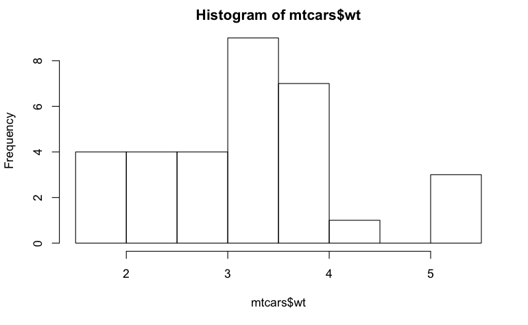

```r
hist(mtcars$wt)
```

**Task 2**: Create a function called `draw_hist()` that takes an atomic vector (of any length) as its input. If it numeric then use the `hist()` function from base to draw a histogram else return an error with a custom message of your choosing using `stop()`.

```r
##create your function
draw_hist <- function(num_vec) {
    if (!is.numeric(num_vec)) stop("Please provide a numeric input")

    hist(num_vec)
}
```

Test your function to make sure it works.

```r
draw_hist(pull(latest_gap, continent)) ## this should throw an error
```

```
Error in draw_hist(pull(latest_gap, continent)) :
  Please provide a numeric input
```

```r
hist(gapminder$country)
```

```
Error in hist.default(gapminder$country) : 'x' must be numeric
```

```r
mean(runif(10), trims = 2)
```

```
[1] 0.4680732
```